# Homework 03 Answers

Load in the dataset “zombies.csv” from my *GitHub* repo at https://github.com/difiore/ADA2016.

```r
library(curl)
f <- curl("https://raw.githubusercontent.com/difiore/ADA2016/master/zombies.csv")
zombies <- read.csv(f, header = TRUE, sep = ",", stringsAsFactors = FALSE)
head(zombies)
```

```
##   id first_name last_name gender   height   weight zombies_killed
## 1  1      Sarah    Little Female 62.88951 132.0872              2
## 2  2       Mark    Duncan   Male 67.80277 146.3753              5
## 3  3    Brandon     Perez   Male 72.12908 152.9370              1
## 4  4      Roger   Coleman   Male 66.78484 129.7418              5
## 5  5      Tammy    Powell Female 64.71832 132.4265              4
## 6  6    Anthony     Green   Male 71.24326 152.5246              1
##   years_of_education                           major      age
## 1                  1                medicine/nursing 17.64275
## 2                  3 criminal justice administration 22.58951
## 3                  1                       education 21.91276
## 4                  6                  energy studies 18.19058
## 5                  3                       logistics 21.10399
## 6                  4                  energy studies 21.48355
```

```r
library(dplyr)
zombies <- select(zombies,gender,height,weight,age,zombies_killed,years_of_education)
head(zombies)
```

```
##   gender   height   weight      age zombies_killed years_of_education
## 1 Female 62.88951 132.0872 17.64275              2                  1
## 2   Male 67.80277 146.3753 22.58951              5                  3
## 3   Male 72.12908 152.9370 21.91276              1                  1
## 4   Male 66.78484 129.7418 18.19058              5                  6
## 5 Female 64.71832 132.4265 21.10399              4                  3
## 6   Male 71.24326 152.5246 21.48355              1                  4
```

[1] Calculate the *population* mean and standard deviation for each quantitative random variable (height, weight, age, number of zombies killed, and years of education).

```r
popsd <- function(x){sqrt(sum((x - mean(x))^2)/(length(x)))}
zombies_summary <- summarize(zombies,mean(height),popsd(height),mean(weight),popsd(weight),mean(age),popsd(age),mean(zombies_killed),popsd(zombies_killed),mean(years_of_education),popsd(years_of_education))
zombies_summary
```

```
##   mean(height) popsd(height) mean(weight) popsd(weight) mean(age)
## 1      67.6301       4.30797     143.9075      18.39186  20.04696
##   popsd(age) mean(zombies_killed) popsd(zombies_killed)
## 1   2.963583                2.992              1.747551
##   mean(years_of_education) popsd(years_of_education)
## 1                    2.996                  1.675704
```

[2] Use {ggplot} and make boxplots of each of these variable by gender.

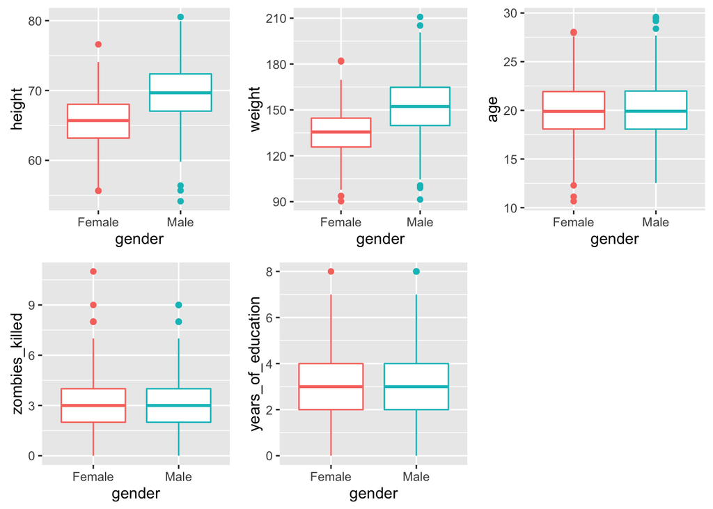

```r
library(ggplot2)
library(gridExtra)
p1 <- ggplot(data=zombies,aes(x=gender, y=height))
p1 <- p1 + geom_boxplot(aes(colour=factor(gender)))
p1 <- p1 + theme(legend.position="none")
p2 <- ggplot(data=zombies,aes(x=gender, y=weight))
p2 <- p2 + geom_boxplot(aes(colour=factor(gender)))
p2 <- p2 + theme(legend.position="none")
p3 <- ggplot(data=zombies,aes(x=gender, y=age))
p3 <- p3 + geom_boxplot(aes(colour=factor(gender)))
p3 <- p3 + theme(legend.position="none")
p4 <- ggplot(data=zombies,aes(x=gender, y=zombies_killed))
p4 <- p4 + geom_boxplot(aes(colour=factor(gender)))
p4 <- p4 + theme(legend.position="none")
p5 <- ggplot(data=zombies,aes(x=gender, y=years_of_education))
p5 <- p5 + geom_boxplot(aes(colour=factor(gender)))
p5 <- p5 + theme(legend.position="none")
grid.arrange(p1,p2,p3,p4,p5, ncol=3)
```

[3] Use {ggplot} and make scatterplots of height and weight in relation to age. Do these variables seem to be related? In what way?

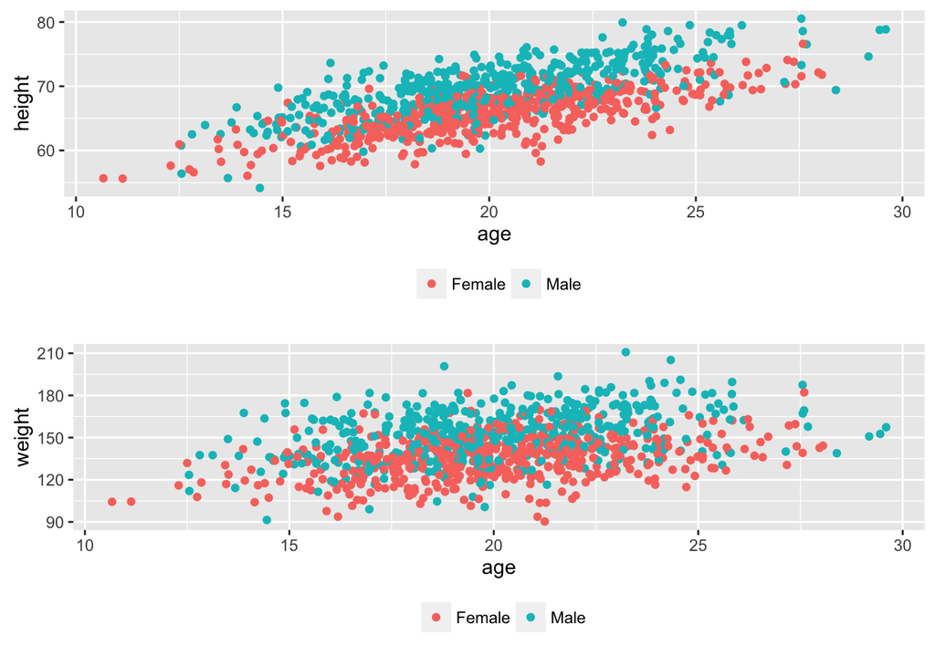

```r
p1 <- ggplot(data=zombies,aes(x=age, y=height, colour=factor(gender)))
p1 <- p1 + geom_point() + theme(legend.position="bottom",legend.title=element_blank())
p2 <- ggplot(data=zombies,aes(x=age, y=weight, colour=factor(gender)))
p2 <- p2 + geom_point() + theme(legend.position="bottom",legend.title=element_blank())
grid.arrange(p1,p2,nrow=2)
```

Both seem to be positive linear functions of age.

[4] Using histograms and Q-Q plots, check whether the quantitative variables seem to be drawn from a normal distribution.

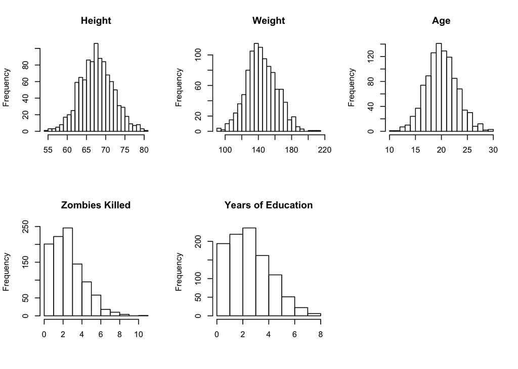

```r
par(mfrow=c(2,3))
hist(zombies$height,main="Height",xlab="",breaks=20)
hist(zombies$weight,main="Weight",xlab="",breaks=20)
hist(zombies$age,main="Age",xlab="",breaks=20)
hist(zombies$zombies_killed,main="Zombies Killed",xlab="",breaks=10)
hist(zombies$years_of_education,main="Years of Education",xlab="",breaks=10)
par(mfrow=c(2,3))
```

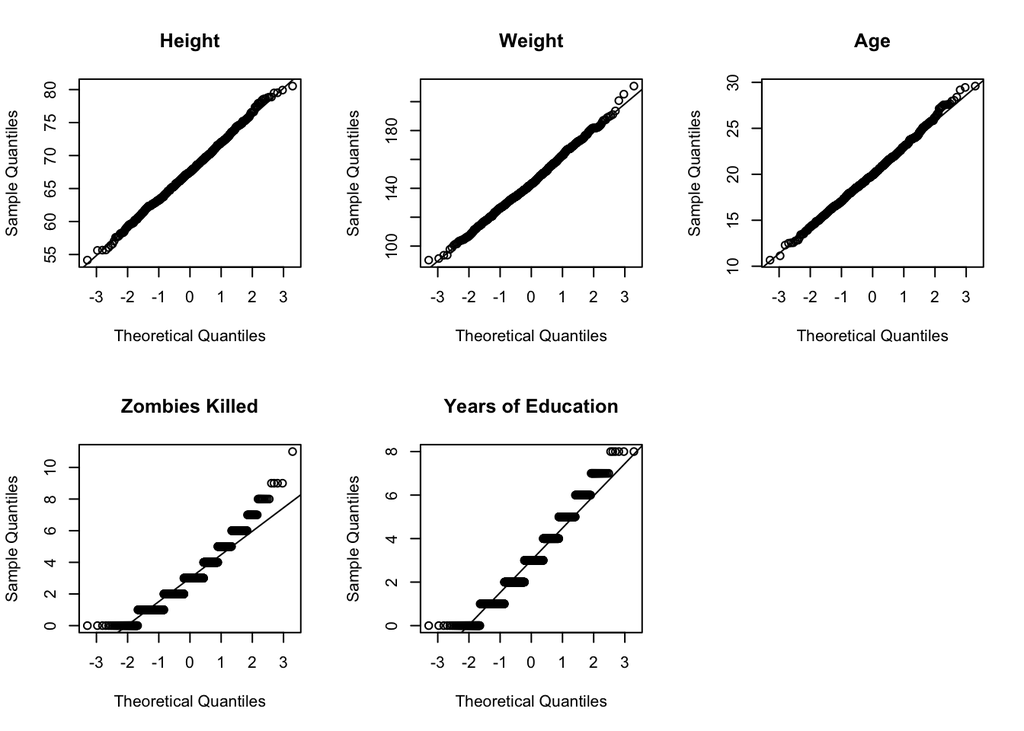

```r
qqnorm(zombies$height,main="Height")
qqline(zombies$height)
qqnorm(zombies$weight,main="Weight")
qqline(zombies$weight)
qqnorm(zombies$age,main="Age")
qqline(zombies$age)
qqnorm(zombies$zombies_killed,main="Zombies Killed")
qqline(zombies$zombies_killed)
qqnorm(zombies$years_of_education,main="Years of Education")
qqline(zombies$years_of_education)
```

The first three are seemingly drawn from the normal, but the latter two no. These are discrete variables and seem to be drawn from the Poisson distribution.

[5] Now use the `sample()` function to sample ONE subset of 30 zombies (without replacement) from this population and calculate the mean and sample standard deviation for each variable. Also estimate the standard error for each variable and construct the 95% confidence interval for each mean. Note that for the variables that are not drawn from the normal distribution, you will need to base your estimate of the CIs on some different distribution.

```r
# first some functions
SE.norm <- function(x){sd(x)/sqrt(length(x))}
SE.pois <- function(x){sqrt(mean(x)/length(x))} # mean(x) is estimate of lambda
CI.norm <- function(x){mean(x) + c(-1,1) * qnorm(1-0.05/2)*SE.norm(x)}
CI.pois.1 <- function(x){mean(x) + c(-1,1) * qnorm(1-0.05/2)*SE.pois(x)} # confidence interval based on normal
CI.pois.2 <- function(x){
    set <- NULL
    for (i in 1:1000){
        set[i] <- mean(sample(x,length(x),replace=TRUE))
  }
    ci <- quantile(set,c(0.025,0.975)) # confidence interval based on simulation
}
CI.pois.3 <- function(x){mean(x) + c(-1,1) * qpois(1-0.05/2,lambda=mean(x))*SE.pois(x)} # this would be a confidence interval based on pois... but this isn't appropriate for this problemt, though, as the sampling distribution for our estimate of lambda should be normal (though the original distribution is Poisson)

n <- 30
zombie_sample <- zombies[sample(1:nrow(zombies),size=n,replace=FALSE),]

zombie_sample_means <- summarize(zombie_sample,mean(height),mean(weight),mean(age),mean(zombies_killed),mean(years_of_education))
zombie_sample_means
```

```
##   mean(height) mean(weight) mean(age) mean(zombies_killed)
## 1     67.39899     145.1707  19.49629                  2.7
##   mean(years_of_education)
## 1                      3.7
```

```r
zombie_sample_sd <- summarize(zombie_sample,sd(height),sd(weight),sd(age),sd(zombies_killed),sd(years_of_education))
zombie_sample_sd
```

```
##   sd(height) sd(weight)  sd(age) sd(zombies_killed) sd(years_of_education)
## 1   4.323087   17.81551 2.843044           1.878187               1.704962
```

```r
zombie_sample_se <- summarize(zombie_sample,SE.norm(height),SE.norm(weight),SE.norm(age),SE.pois(zombies_killed),SE.pois(years_of_education))
zombie_sample_se
```

```
##   SE.norm(height) SE.norm(weight) SE.norm(age) SE.pois(zombies_killed)
## 1       0.7892841        3.252652    0.5190665                     0.3
##   SE.pois(years_of_education)
## 1                   0.3511885
```

```r
zombie_sample_cis <- c(CI.norm(zombie_sample$height),CI.norm(zombie_sample$weight),CI.norm(zombie_sample$age),CI.pois.1(zombie_sample$zombies_killed),CI.pois.2(zombie_sample$zombies_killed),CI.pois.1(zombie_sample$years_of_education),CI.pois.2(zombie_sample$years_of_education))
names(zombie_sample_cis) <- rep(c("2.5%","97.5%"),7)
zombie_sample_cis
```

```
##       2.5%      97.5%       2.5%      97.5%       2.5%      97.5%
##  65.852022  68.945959 138.795629 151.545790  18.478941  20.513644
##       2.5%      97.5%       2.5%      97.5%       2.5%      97.5%
##   2.112011   3.287989   2.066667   3.400000   3.011683   4.388317
##       2.5%      97.5%
##   3.165833   4.300000
```

[6] Now draw 99 more random samples of 30 zombies out and calculate the mean for each variable for each of the these samples. Together with the first sample you drew out, you now have a set of 100 means for each variable (each based on 30 observations), which constitutes a sampling distribution for each variable. What are the means and standard deviations of this distribution of means for each variable? How do the standard deviations of means compare to the standard errors estimated in [5]?

```r
s <- NULL # zombie samples
s[[1]]<-zombie_sample # start a data frame of sample means with initial sample
for (i in 2:100){
    s[[i]] <- zombies[sample(1:nrow(zombies),size=n,replace=FALSE),]
}
head(s,1)
```

```
## [[1]]
##     gender   height   weight      age zombies_killed years_of_education
## 809   Male 69.61105 144.9560 21.90370              2                  3
## 587   Male 73.02198 160.7283 22.56667              2                  3
## 642 Female 69.78112 149.1819 24.24839              1                  2
## 807   Male 72.15756 174.6401 21.91014              2                  7
## 873 Female 63.39950 134.4014 17.77331              5                  2
## 971 Female 68.42884 150.9425 19.22270              0                  5
## 643   Male 67.18481 163.1978 18.15892              3                  2
## 756 Female 60.74299 124.3453 16.33405              2                  2
## 715   Male 68.47676 162.6529 16.00533              6                  3
## 618 Female 62.32428 125.1633 17.56003              2                  7
## 856   Male 76.44105 172.9885 23.49016              1                  3
## 654 Female 59.74804 132.6426 15.43728              2                  2
## 18  Female 62.74435 127.1145 19.58134              3                  5
```

[output cut: 17 more lines]

```r
sd <- NULL # zombie sampling distributions
for (i in 1:100){
    sd <- rbind(sd,summarize(s[[i]],mean(height),mean(weight),mean(age),mean(zombies_killed),mean(years_of_education)))
}
head(sd)
```

```
##   mean(height) mean(weight) mean(age) mean(zombies_killed)
## 1     67.39899     145.1707  19.49629             2.700000
## 2     67.57964     144.7668  19.39009             3.166667
## 3     68.17549     145.2763  20.81447             3.200000
## 4     67.95867     144.7559  19.97729             3.233333
## 5     68.07503     149.4264  19.14499             3.033333
## 6     68.78802     147.3436  20.66383             2.833333
##   mean(years_of_education)
## 1                 3.700000
## 2                 2.600000
## 3                 3.033333
## 4                 3.033333
## 5                 3.200000
## 6                 2.866667
```

```r
final <- summarize(sd,mean(`mean(height)`),sd(`mean(height)`),mean(`mean(weight)`),sd(`mean(weight)`),mean(`mean(age)`),sd(`mean(age)`),mean(`mean(zombies_killed)`),sd(`mean(zombies_killed)`),mean(`mean(years_of_education)`),sd(`mean(years_of_education)`))
names(final) <- c("mean_mean_height","sd_mean_height","mean_mean_weight","sd_mean_weight","mean_mean_age","sd_mean_age","mean_mean_zombies_killed","sd_mean_zombies_killed","mean_mean_years_of_education","sd_mean_years_of_education")
final
```

```
##   mean_mean_height sd_mean_height mean_mean_weight sd_mean_weight
## 1         67.65217       0.737798          144.175        2.86513
##   mean_mean_age sd_mean_age mean_mean_zombies_killed
## 1       20.0124    0.547971                 2.942667
##   sd_mean_zombies_killed mean_mean_years_of_education
## 1              0.3022207                     3.041667
##   sd_mean_years_of_education
## 1                  0.3031216
```

```r
# Compare SD of sampling distribution to SE estimated from a single sample and to SE estimated based on what we know of population and sample size. These should all be about the same! As number of samples increases, the SD of the sampling distribution should converge to the standard error, i.e., to population standard deviation/sqrt(n). The SE of each sample should be an estimator of this standard error.

# height
compare_height <- c(final$sd_mean_height,zombie_sample_se$`SE.norm(height)`,popsd(zombies$height/sqrt(n)))

# weight
compare_weight <- c(final$sd_mean_weight,zombie_sample_se$`SE.norm(weight)`,popsd(zombies$weight/sqrt(n)))

# age
compare_age <- c(final$sd_mean_age,zombie_sample_se$`SE.norm(age)`,popsd(zombies$age/sqrt(n)))

# zombies_killed
compare_zombies_killed <- c(final$sd_mean_zombies_killed,zombie_sample_se$`SE.pois(zombies_killed)`,popsd(zombies$zombies_killed/sqrt(n)))

# years_of_education
compare_years_of_education <- c(final$sd_mean_years_of_education,zombie_sample_se$`SE.pois(years_of_education)`,popsd(zombies$years_of_education/sqrt(n)))

compare <- data.frame(rbind(compare_height,compare_weight,compare_age,compare_zombies_killed,compare_years_of_education))
names(compare) <- c("sd of sampling dist","se from single sample","se from population sd and n")
compare
```

```
##                            sd of sampling dist se from single sample
## compare_height                       0.7377980             0.7892841
## compare_weight                       2.8651304             3.2526518
## compare_age                          0.5479710             0.5190665
## compare_zombies_killed               0.3022207             0.3000000
## compare_years_of_education           0.3031216             0.3511885
##                            se from population sd and n
## compare_height                               0.7865241
## compare_weight                               3.3578783
## compare_age                                  0.5410737
## compare_zombies_killed                       0.3190578
## compare_years_of_education                   0.3059403
```

What do these sampling distributions look like? Are they normally distributed? What about for those variables that you concluded were not originally drawn from a normal distribution?

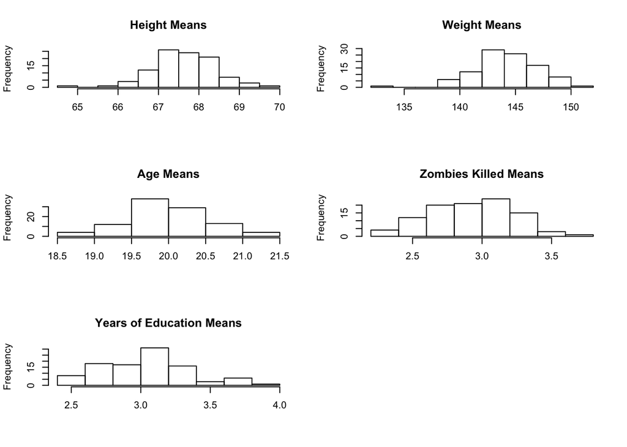

```r
# plot the distributions
par(mfrow=c(3,2))
hist(sd$`mean(height)`,main="Height Means",xlab="")
hist(sd$`mean(weight)`,main="Weight Means",xlab="")
hist(sd$`mean(age)`,main="Age Means",xlab="")
hist(sd$`mean(zombies_killed)`,main="Zombies Killed Means",xlab="")
hist(sd$`mean(years_of_education)`,main="Years of Education Means",xlab="")

par(mfrow=c(2,3))
```

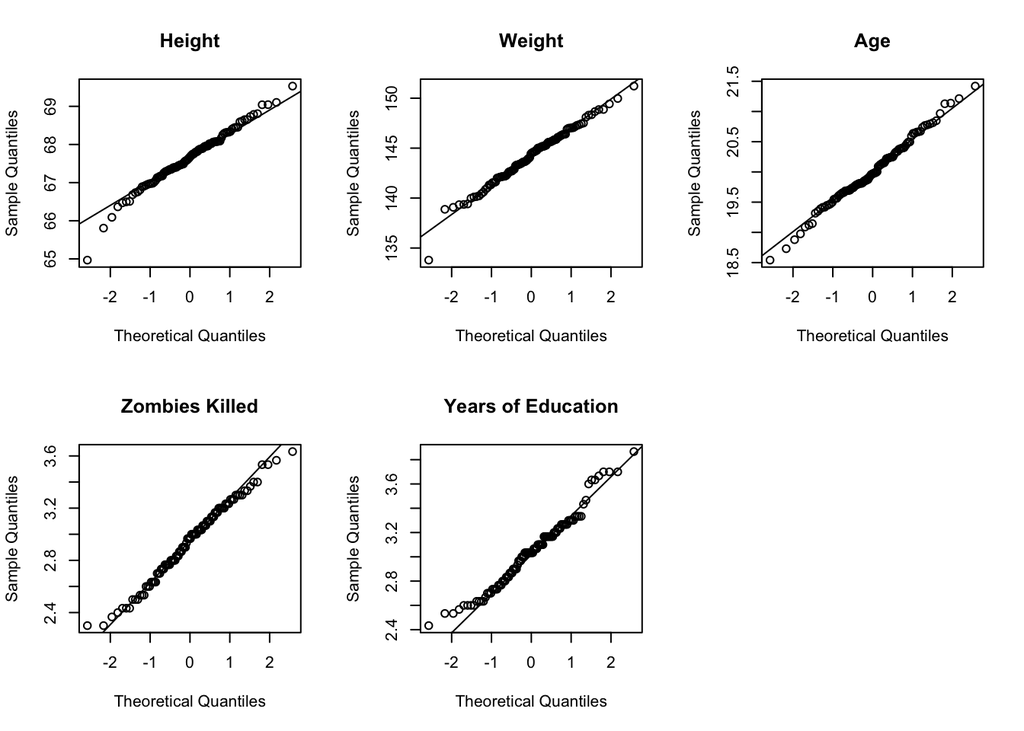

```r
qqnorm(sd$`mean(height)`,main="Height")
qqline(sd$`mean(height)`)
qqnorm(sd$`mean(weight)`,main="Weight")
qqline(sd$`mean(weight)`)
qqnorm(sd$`mean(age)`,main="Age")
qqline(sd$`mean(age)`)
qqnorm(sd$`mean(zombies_killed)`,main="Zombies Killed")
qqline(sd$`mean(zombies_killed)`)
qqnorm(sd$`mean(years_of_education)`,main="Years of Education")
qqline(sd$`mean(years_of_education)`)
```

These all look more normally distributed now.